# Functions

Author

Dr. D

So here is the binomial function.

$$P(N_A|N,N_A,p) = \frac{2N!}{N_A!(2N-N_A)!}p^{N_A} (1-p)^{2N-N_A}$$
If you are estimating $P(N_A|N,N_A,p)$ then we need to make code that will be put into a function. I start by specifying some of the parameters that are going to go into this function.

```r
N <- 30
Na <- 14
p <- 0.6
```

And then make the code that does the calculation for these parameters.

```r
num <- factorial( 2*N )
denom <- factorial( Na) * factorial(2*N - Na)
prob <- p^Na * (1-p)^(2*N-Na)
res <- num/denom *prob
res
```

```
[1] 6.730912e-09
```

**Always** check your answer. Is it giving me something that is *vaguely* correct? This should produce a probability, is the answer a probability?

Then, warp the code into a function:

```r
binomial_prob <- function( N, Na, p ) {
  num <- factorial( 2*N )
  denom <- factorial( Na) * factorial(2*N - Na)
  prob <- p^Na * (1-p)^(2*N-Na)
  res <- num/denom *prob
  return( res )
}
```

Now test it with some other values.

```r
binomial_prob(20,20,0.5)
```

```
[1] 0.1253707
```

## Making a scenario

So let’s estimate a situation where we look at the probability of values of $Na$ that are reasonable. In a diploid organism, we can have 0, 1, 2, … , 2*N copies of the $A$ allele. So, let’s make a data.frame object that has a column for the numbrer of $Na$ alleles at the next generation.

```r
N <- 40
data.frame( Na = 0:(2*N) ) -> df

# look at it.
summary( df )
```

```
       Na
 Min.   : 0
 1st Qu.:20
 Median :40
 Mean   :40
 3rd Qu.:60
 Max.   :80
```

Let’s also now add a column for the probabilities associated with each of these $Na$ values. I like to fill it with missing data, $NA$, so if I mess something up, it does not have values that I may mistake for data in it.

```r
df$p <- NA

# look at it.
summary( df )
```

```
       Na        p
 Min.   : 0   Mode:logical
 1st Qu.:20   NA's:81
 Median :40
 Mean   :40
 3rd Qu.:60
 Max.   :80
```

Now, let’s use the `rowwise()` function from `tidyverse` to go through this data.frame and estimate the probabilities for each of these.

```r
library( tidyverse )
df |>
  rowwise() |>
  mutate( p = binomial_prob( 40, Na, 0.5 ) )
```

```
# A tibble: 81 × 2
# Rowwise:
      Na        p
   <int>    <dbl>
 1     0 8.27e-25
 2     1 6.62e-23
 3     2 2.61e-21
 4     3 6.80e-20
 5     4 1.31e-18
 6     5 1.99e-17
 7     6 2.49e-16
 8     7 2.63e-15
 9     8 2.40e-14
10     9 1.92e-13
# ℹ 71 more rows
```

It looks like it gave me something that is reasonable…

So now, lets take that and pipe it into `ggplot` to make a graph.

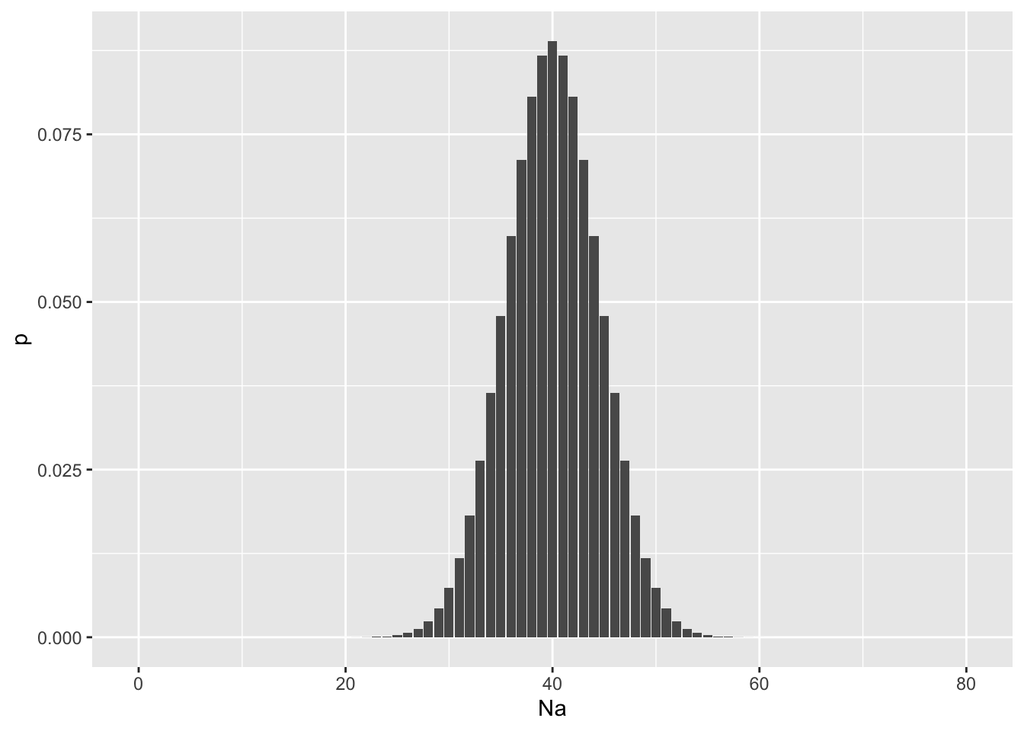

```r
df |>
  rowwise() |>
  mutate( p = binomial_prob( 40, Na, 0.5 ) ) |>
  ggplot( aes( Na, p ) ) +
  geom_col()
```

Perfect.